# Image Power: Vizualizing Matrices

Thomas Manke

5 Dec 2016

# Image:

Rather than looking at all pairwise correlation coefficients, it is often easier to visualize them as a colour-coded matrix image.

```r
niris=iris[,-5]
C=cor(niris)
C
```

```
##              Sepal.Length Sepal.Width Petal.Length Petal.Width
## Sepal.Length    1.0000000  -0.1175698    0.8717538   0.8179411
## Sepal.Width    -0.1175698   1.0000000   -0.4284401  -0.3661259
## Petal.Length    0.8717538  -0.4284401    1.0000000   0.9628654
## Petal.Width     0.8179411  -0.3661259    0.9628654   1.0000000
```

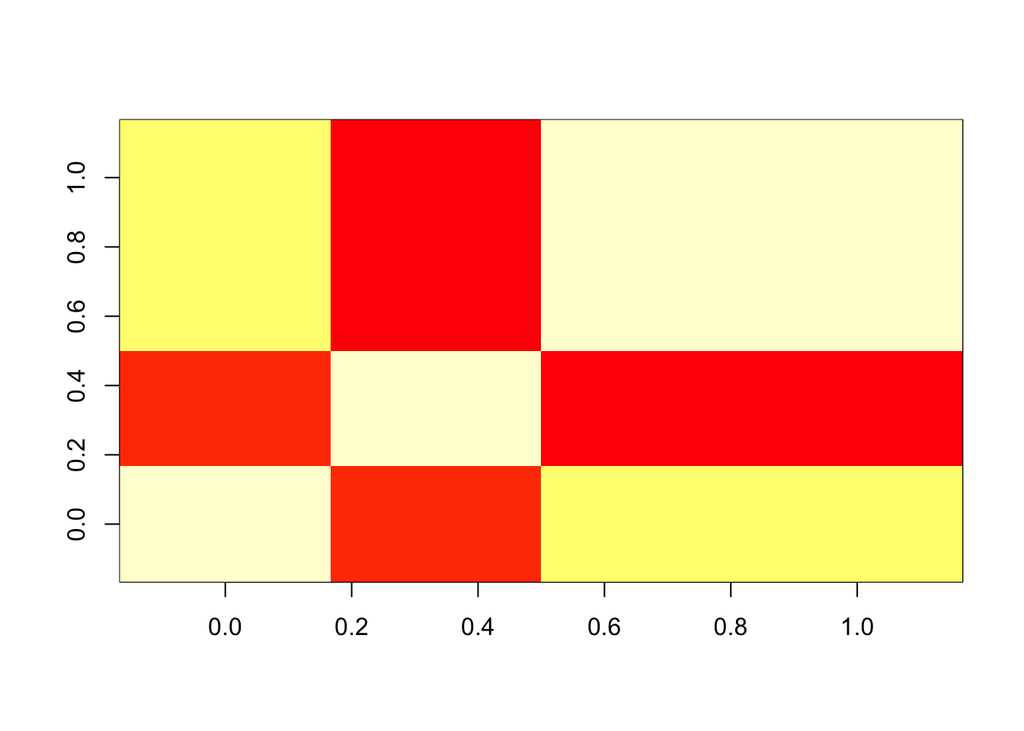

```r
image(C)
```

**Task**: Using the image() call, try to reproduce the following image for the full iris data (not just its correlation matrix)

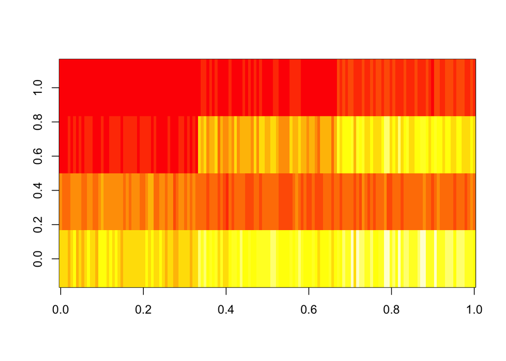

Be aware:

- Columns (=variables) appear as rows in image(). How could this be changed?
- the axes are meaningless. Default: $0 \ldots 1$
- there is a large difference in scales for the different variables
- there is an implicit color-scheme: which one?

Below we are re-scaling the iris-matrix

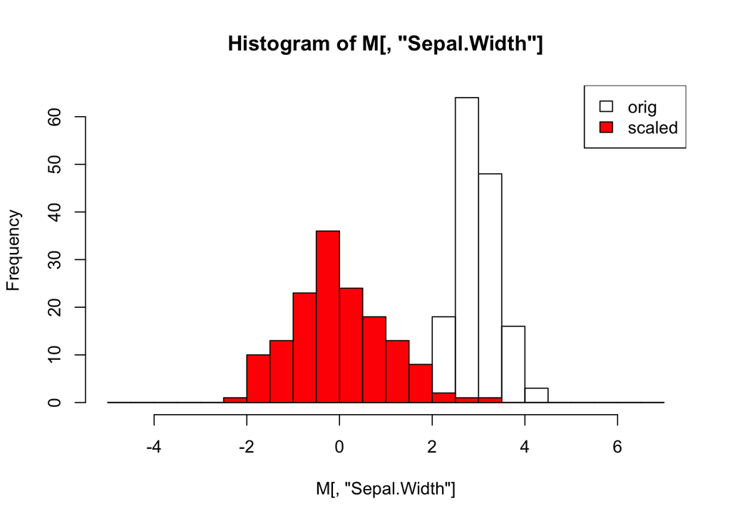

```r
S=scale(M)            # scales column-wise
br=seq(-5,7,by=0.5)   # set common break points for the histograms below
hist(M[,"Sepal.Width"], breaks = br)
hist(S[,"Sepal.Width"], breaks = br, add=TRUE, col="red")      # add histogram to current plot
legend("topright", c("orig","scaled"), fill=c("white", "red"))
```

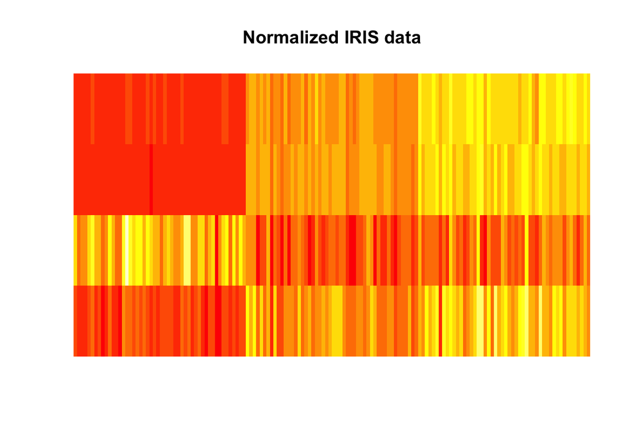

```r
image(S,main="Normalized IRIS data", axes=FALSE)              # as before, suppress axes
```

```r
#add axes flexibly
#axis(4,at=seq(0,1,length.out=ncol(S)), labels=colnames(S), las=2) # Understand this command
```

## Heatmaps

Heatmaps are advanced images in which rows and columns are re-ordered according to some distance measure (default: Euclidean) and hierarchical clustering method (default: complete)

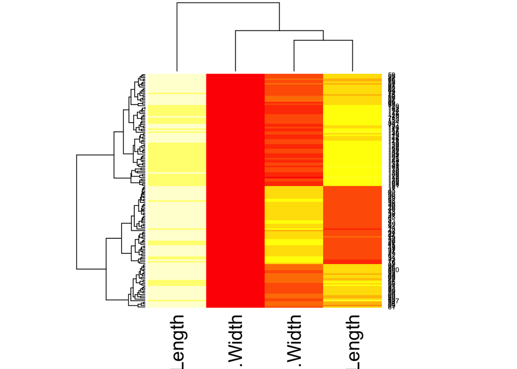

```r
heatmap(M)
```

Notice that:

- unlike image(), the heatmap is already in the “canonical” orientation
- the heatmap is usually scaled by rows (columns more useful)
- frequently needs many customizations: label size, remove row-names, …
- there is an implicit colour scheme: “numerical value $\to$ colour”
- there are multiple extensions of this in other R-packages: e.g. gplots::heatmap.2

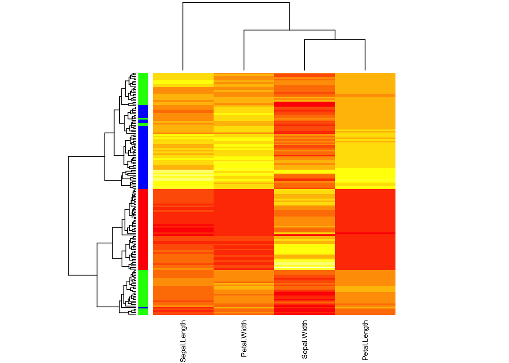

```r
cols <- rainbow(3)[iris$Species]  # understand how color is defined
heatmap(M,scale="col", RowSideColors=cols,labRow=FALSE, cexCol=0.9)
```

# Sending plots to files

In Rstudio, we can export figures from the “Plots” tab. On the console we can define a pdf file as a new device for all subsequent figures. This is usually done only *after* the image is sufficiently optimized

```r
pdf("../data/heatmap.pdf") # similar for jpeg, png, ...
heatmap(M,scale="col", RowSideColors=cols,labRow=FALSE, cexCol=0.9)
dev.off()  # close device = pdf file
```

# Dimensional Reduction: PCA

```r
D=as.matrix(iris[,-5])     # numerical data, some operations below require matrices not data frames (%*%)
s=iris[,5]                 # species attributes (factor)
```

# Goals:

- simplify description of data matrix $D$: data reduction & extract most important information
- maximal variance: look for direction in which data shows maximal variation
- minimal error: allow accurate reconstruction of original data

```r
pca=prcomp(D, scale=TRUE)
```

*Task*: What kind of object is pca?

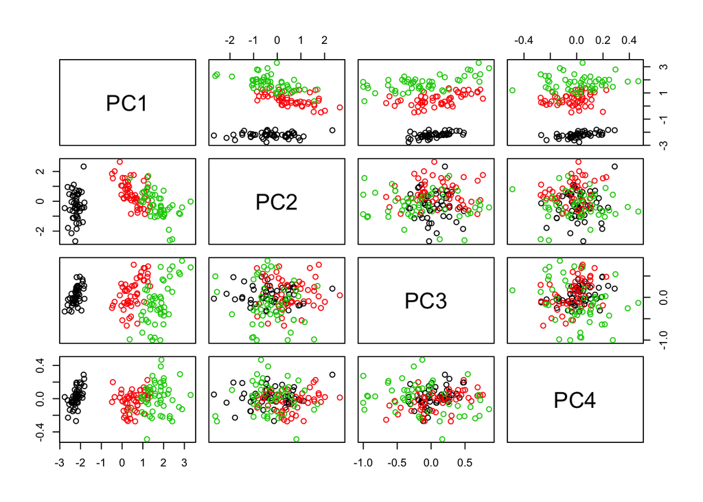

```r
R=pca$rotation  # rotation matrix
S=pca$x         # score matrix = rotated scaled data matrix = Ds %*% R
pairs(S, col=s) #
```

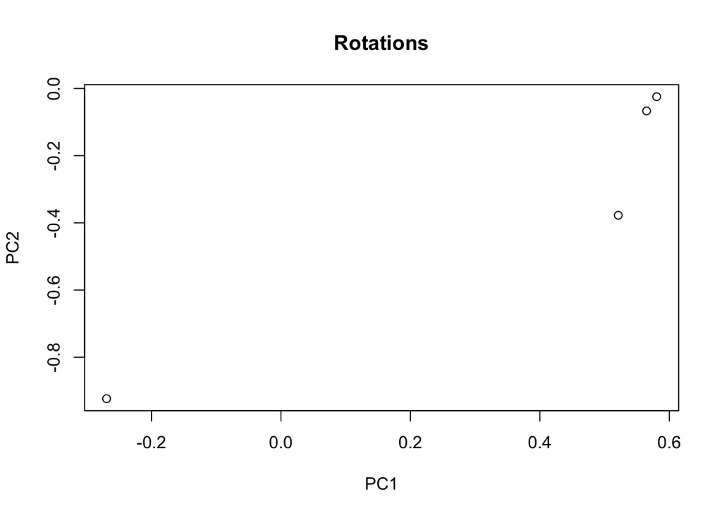

```r
plot(R[,1:2], main="Rotations")
```

```r
# covariance matrix of scores is diagonal (by design)
# --> principal components are uncorrelated
CS=cov(S)   # = t(S) %*% S / (nrow(S) - 1)
CS
```

```
##               PC1           PC2           PC3           PC4
## PC1  2.918498e+00  4.746835e-16 -3.125780e-16  5.294859e-16
## PC2  4.746835e-16  9.140305e-01  3.421466e-17 -3.178229e-17
## PC3 -3.125780e-16  3.421466e-17  1.467569e-01 -7.636317e-17
## PC4  5.294859e-16 -3.178229e-17 -7.636317e-17  2.071484e-02
```

Notice that the higher components do not add much information, so we may as well represent the transformed data in only the first two dimensions:

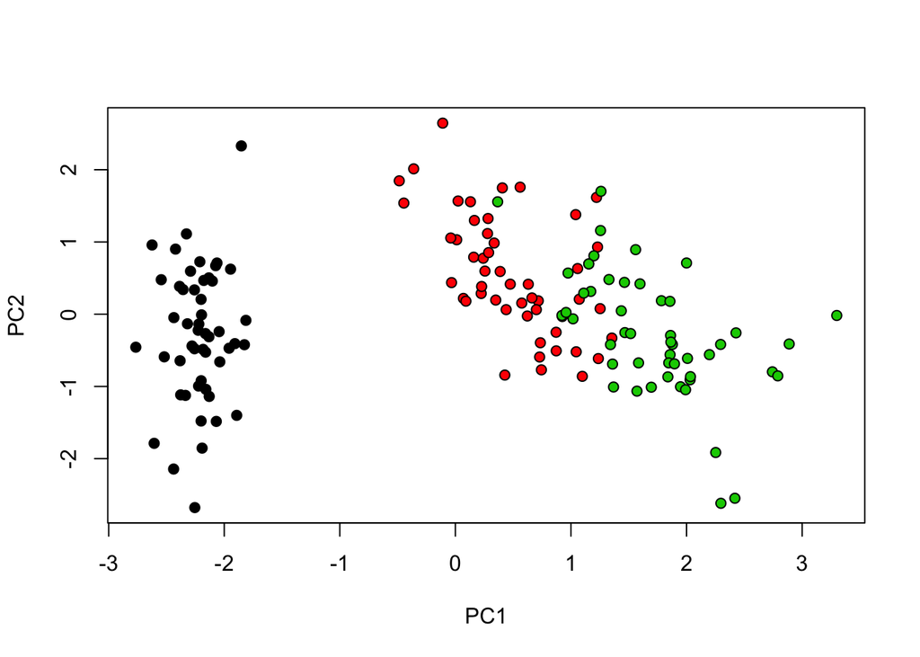

```r
plot(S[,1:2],pch=21, bg=s)  # score-plot
```

A biplot represents both the observations and the old variables in a new coordinate system (up-to-rescaling)

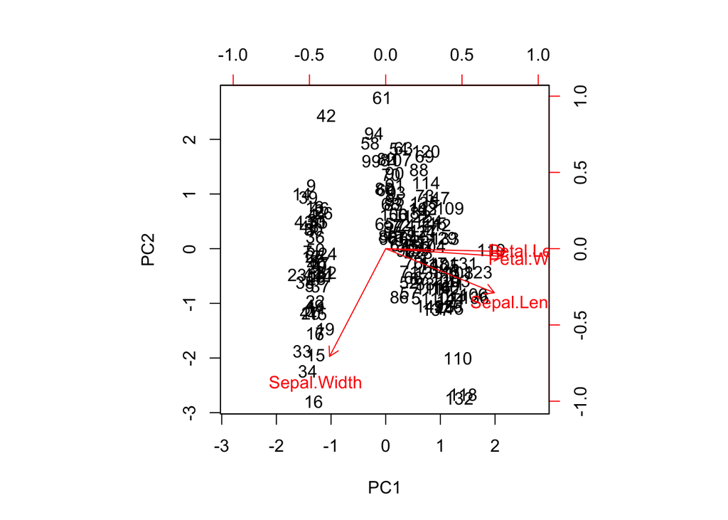

```r
biplot(pca, pc.biplot = TRUE)
```

# Review:

- use image() and heatmap() to visualize matrices
- customization of plots again: colours, legends
- fallacies of colour-scaling
- exporting figures as publication-ready files
- dimensional reduction with PCA